# Case Study- Cyclistic Bike Share Analysis

Vineet

14 June 2021

## Introduction

A case study on a fictional company, Cyclistic, that runs a bike-sharing program in the city of Chicago

## Purpose

- To analyze data of all bike rides taken through the program between May 2020 to Apr 2021
- To maximize the number of annual memberships
- To understand how the two types of riders, i.e. Casual and Member, use the program differently
- To reccomend strategies to convert casual riders into members

## Data

We’re using historical data from divvy, a bike sharing service in Chicago operated by Motivate International Inc. The data is public, reliable and from a credile source

```r
# Load R Packages to use
library(tidyverse)
library(lubridate)
```

```r
library(ggplot2)
library(scales)
library(geosphere)
```

## Collect and Read Data

```r
#============================
#STEP 1 COLLECT AND READ DATA
#============================

# Read csv files

df1 <- read_csv("../Data/divvy/bikeshare-trip-details-data/01_May_2020.csv")
df2 <- read_csv("../Data/divvy/bikeshare-trip-details-data/02_Jun_2020.csv")
df3 <- read_csv("../Data/divvy/bikeshare-trip-details-data/03_Jul_2020.csv")
df4 <- read_csv("../Data/divvy/bikeshare-trip-details-data/04_Aug_2020.csv")
df5 <- read_csv("../Data/divvy/bikeshare-trip-details-data/05_Sept_2020.csv")
df6 <- read_csv("../Data/divvy/bikeshare-trip-details-data/06_Oct_2020.csv")
df7 <- read_csv("../Data/divvy/bikeshare-trip-details-data/07_Nov_2020.csv")
df8 <- read_csv("../Data/divvy/bikeshare-trip-details-data/08_Dec_2020.csv")
df9 <- read_csv("../Data/divvy/bikeshare-trip-details-data/09_Jan_2021.csv")
df10 <- read_csv("../Data/divvy/bikeshare-trip-details-data/10_Feb_2021.csv")
df11 <- read_csv("../Data/divvy/bikeshare-trip-details-data/11_Mar_2021.csv")
df12 <- read_csv("../Data/divvy/bikeshare-trip-details-data/12_Apr_2021.csv")
```

## Wrangle and Combine Data

```r
#=================================
#STEP 2 - WRANGLE AND COMBINE DATA
#=================================

# Fix data type issues with columns
df1$started_at <- as.POSIXct(df1$started_at, format="%m/%d/%Y %H:%M")
df1$ended_at <- as.POSIXct(df1$ended_at, format="%m/%d/%Y %H:%M")
df2$started_at <- as.POSIXct(df2$started_at, format="%m/%d/%Y %H:%M")
df2$ended_at <- as.POSIXct(df2$ended_at, format="%m/%d/%Y %H:%M")

df8$start_station_id <- as.double(df8$start_station_id)
df8$end_station_id <- as.double(df8$end_station_id)
df9$start_station_id <- as.double(df9$start_station_id)
df9$end_station_id <- as.double(df9$end_station_id)
df10$start_station_id <- as.double(df10$start_station_id)
df10$end_station_id <- as.double(df10$end_station_id)
df11$start_station_id <- as.double(df11$start_station_id)
df11$end_station_id <- as.double(df11$end_station_id)
df12$start_station_id <- as.double(df12$start_station_id)
df12$end_station_id <- as.double(df12$end_station_id)
```

```
## Warning: NAs introduced by coercion
```

```r
# Combine all data to a single dataframe
df_all_trips = bind_rows(df1, df2, df3, df4, df5, df6, df7, df8, df9, df10, df11, df12)
head(df_all_trips)
```

```
## # A tibble: 6 x 13
##   ride_id rideable_type started_at          ended_at            start_station_n~
##   <chr>   <chr>         <dttm>              <dttm>              <chr>
## 1 7C754A~ docked_bike   2020-04-30 18:32:00 2020-04-30 18:50:00 Michigan Ave & ~
## 2 9BD98D~ docked_bike   2020-04-30 18:34:00 2020-04-30 18:45:00 Wilton Ave & Be~
## 3 11190B~ docked_bike   2020-04-30 18:35:00 2020-04-30 18:51:00 Damen Ave & Wel~
## 4 3FEA7C~ docked_bike   2020-04-30 18:37:00 2020-04-30 19:00:00 St. Clair St & ~
## 5 E76405~ docked_bike   2020-04-30 18:37:00 2020-04-30 18:43:00 Damen Ave & Sun~
## 6 28295B~ docked_bike   2020-04-30 18:37:00 2020-04-30 18:45:00 State St & 33rd~
## # ... with 8 more variables: start_station_id <dbl>, end_station_name <chr>,
## #   end_station_id <dbl>, start_lat <dbl>, start_lng <dbl>, end_lat <dbl>,
## #   end_lng <dbl>, member_casual <chr>
```

*Note: We’re ignoring the warnings caused because of “NA” values introduced while converting start_station_id & end_station_id to integer. This won’t impact our analysis*

```r
# SUMMARY
summary(df_all_trips)
```

```
##    ride_id          rideable_type        started_at
##  Length:3742202     Length:3742202     Min.   :2020-04-30 18:32:00
##  Class :character   Class :character   1st Qu.:2020-07-23 19:27:14
##  Mode  :character   Mode  :character   Median :2020-09-09 15:51:13
##                                        Mean   :2020-10-02 23:47:54
##                                        3rd Qu.:2020-11-15 17:49:27
##                                        Max.   :2021-04-30 23:59:53
##
##     ended_at                   start_station_name start_station_id
##  Min.   :2020-04-30 18:43:00   Length:3742202     Min.   :     2
##  1st Qu.:2020-07-23 19:59:58   Class :character   1st Qu.:   112
##  Median :2020-09-09 16:08:31   Mode  :character   Median :   226
##  Mean   :2020-10-03 00:12:22                      Mean   :  1536
##  3rd Qu.:2020-11-15 18:05:29                      3rd Qu.:   349
##  Max.   :2021-05-05 22:14:39                      Max.   :202480
##                                                   NA's   :588278
##  end_station_name   end_station_id     start_lat       start_lng
##  Length:3742202     Min.   :     2   Min.   :41.64   Min.   :-87.87
##  Class :character   1st Qu.:   112   1st Qu.:41.88   1st Qu.:-87.66
##  Mode  :character   Median :   226   Median :41.90   Median :-87.64
##                     Mean   :  1537   Mean   :41.90   Mean   :-87.64
##                     3rd Qu.:   349   3rd Qu.:41.93   3rd Qu.:-87.63
##                     Max.   :202480   Max.   :42.08   Max.   :-87.52
##                     NA's   :604846
##     end_lat         end_lng       member_casual
##  Min.   :41.54   Min.   :-88.07   Length:3742202
##  1st Qu.:41.88   1st Qu.:-87.66   Class :character
##  Median :41.90   Median :-87.64   Mode  :character
##  Mean   :41.90   Mean   :-87.64
##  3rd Qu.:41.93   3rd Qu.:-87.63
##  Max.   :42.16   Max.   :-87.44
##  NA's   :4906    NA's   :4906
```

There are NA values in end_lat & end_lng columns. We will set these NA values with their respective mean values

```r
#=================================================
# STEP 3: CLEAN DATA AND PREPARE DATA FOR ANALYSIS
#=================================================

#Set NA to mean value to ride's end coordinates
df_all_trips$end_lat[is.na(df_all_trips$end_lat)] <- mean(df_all_trips$end_lat, na.rm = TRUE)
df_all_trips$end_lng[is.na(df_all_trips$end_lng)] <- mean(df_all_trips$end_lng, na.rm = TRUE)

# Add new columns for analysis
df_all_trips$ride_length <- df_all_trips$ended_at - df_all_trips$started_at
df_all_trips <- df_all_trips %>%
  mutate(dist_travelled = distHaversine(cbind(start_lat, start_lng), cbind(end_lat, end_lng)))

df_all_trips$date <- as.Date(df_all_trips$started_at)
df_all_trips$day <- format(df_all_trips$date, "%d")
df_all_trips$day_of_week <- weekdays(as.Date(df_all_trips$started_at))
df_all_trips$month <- months(df_all_trips$date)
df_all_trips$year <- format(df_all_trips$date, "%Y")

# Review data with newly added columns arranged by ride_length
head(arrange(df_all_trips, ride_length))
```

```
## # A tibble: 6 x 20
##   ride_id rideable_type started_at          ended_at            start_station_n~
##   <chr>   <chr>         <dttm>              <dttm>              <chr>
## 1 3ED2B8~ electric_bike 2020-12-15 12:10:14 2020-11-25 08:00:16 Wells St & Conc~
## 2 6DF34F~ electric_bike 2020-12-15 11:35:39 2020-11-25 07:40:56 Sheffield Ave &~
## 3 BE1F69~ docked_bike   2020-12-15 11:34:23 2020-11-25 08:00:15 Kingsbury St & ~
## 4 321F7A~ docked_bike   2020-12-15 12:12:43 2020-11-25 08:42:16 Dayton St & Nor~
## 5 BB4697~ docked_bike   2020-12-15 11:34:38 2020-11-25 08:09:43 Clark St & 9th ~
## 6 05498B~ docked_bike   2020-12-15 12:11:52 2020-11-25 08:51:27 Clinton St & Ma~
## # ... with 15 more variables: start_station_id <dbl>, end_station_name <chr>,
## #   end_station_id <dbl>, start_lat <dbl>, start_lng <dbl>, end_lat <dbl>,
## #   end_lng <dbl>, member_casual <chr>, ride_length <drtn>,
## #   dist_travelled <dbl>, date <date>, day <chr>, day_of_week <chr>,
## #   month <chr>, year <chr>
```

There are -ve values in the ride_length column that don’t make sense. We will remove these values from our analysis

```r
#==========================================================
# STEP 3: CLEAN DATA AND PREPARE DATA FOR ANALYSIS (contd.)
#==========================================================

# Check number of records and Remove trips with negative ride length
cat("Original no of Rows = ",nrow(df_all_trips),'\n')
```

```
## Original no of Rows =  3742202
```

```r
cat("No of Rows with ride duration < 0 seconds = ", sum(df_all_trips$ride_length < 0),'\n')
```

```
## No of Rows with ride duration < 0 seconds =  9951
```

```r
df_all_trips_v2 <- df_all_trips[!(df_all_trips$ride_length < 0),]
cat("Updated no of Rows = ", nrow(df_all_trips_v2))
```

```
## Updated no of Rows =  3732251
```

```r
# Order day_of_week to start from Monday and months to start from May '20
df_all_trips_v2$day_of_week <- ordered(df_all_trips_v2$day_of_week, levels=c("Monday", "Tuesday", "Wednesday", "Thursday", "Friday", "Saturday", "Sunday"))
df_all_trips_v2$month <- ordered(df_all_trips_v2$month, levels=c("May", "June", "July", "August", "September", "October", "November", "December", "January", "February", "March", "April"))

# View updated dataframe
head(df_all_trips_v2)
```

```
## # A tibble: 6 x 20
##   ride_id rideable_type started_at          ended_at            start_station_n~
##   <chr>   <chr>         <dttm>              <dttm>              <chr>
## 1 7C754A~ docked_bike   2020-04-30 18:32:00 2020-04-30 18:50:00 Michigan Ave & ~
## 2 9BD98D~ docked_bike   2020-04-30 18:34:00 2020-04-30 18:45:00 Wilton Ave & Be~
## 3 11190B~ docked_bike   2020-04-30 18:35:00 2020-04-30 18:51:00 Damen Ave & Wel~
## 4 3FEA7C~ docked_bike   2020-04-30 18:37:00 2020-04-30 19:00:00 St. Clair St & ~
## 5 E76405~ docked_bike   2020-04-30 18:37:00 2020-04-30 18:43:00 Damen Ave & Sun~
## 6 28295B~ docked_bike   2020-04-30 18:37:00 2020-04-30 18:45:00 State St & 33rd~
## # ... with 15 more variables: start_station_id <dbl>, end_station_name <chr>,
## #   end_station_id <dbl>, start_lat <dbl>, start_lng <dbl>, end_lat <dbl>,
## #   end_lng <dbl>, member_casual <chr>, ride_length <drtn>,
## #   dist_travelled <dbl>, date <date>, day <chr>, day_of_week <ord>,
## #   month <ord>, year <chr>
```

## Analyze Data

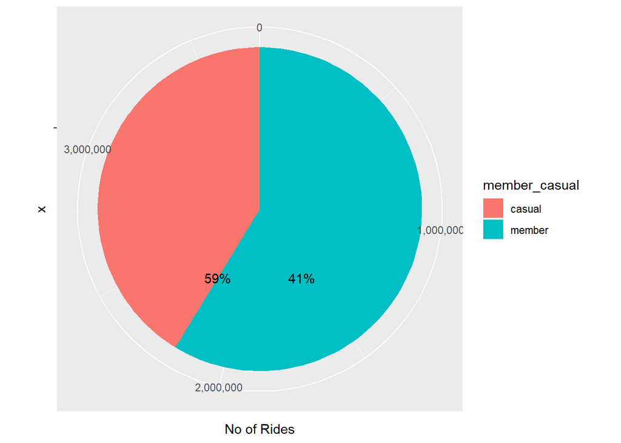

```r
#=====================
# STEP 4: ANALYZE DATA
#=====================

# Reduce tendency to display axis values in Scientific notation
options(scipen = 100)

# 1) Proportion of rides taken by rider type
ggp1 <- df_all_trips_v2 %>%
  group_by(member_casual) %>%
  summarise(number_of_rides = n()) %>%
  arrange(member_casual) %>%
  ggplot(aes(x = "",y = number_of_rides, fill = member_casual)) + geom_bar(stat="identity", width=1) + coord_polar("y", start=0)
ggp1 + labs(y="No of Rides") + scale_y_continuous(labels = comma) + geom_text(aes(label = percent(number_of_rides/sum(number_of_rides))))
```

#### Analysis:

- In the last 12 months, i.e. May ’20 to Apr ’21, a considerable amount of rides have been taken by casual riders (41%)

#### Thus, a great opportunity lies here to convert the casual riders to members. This calls for further analysis

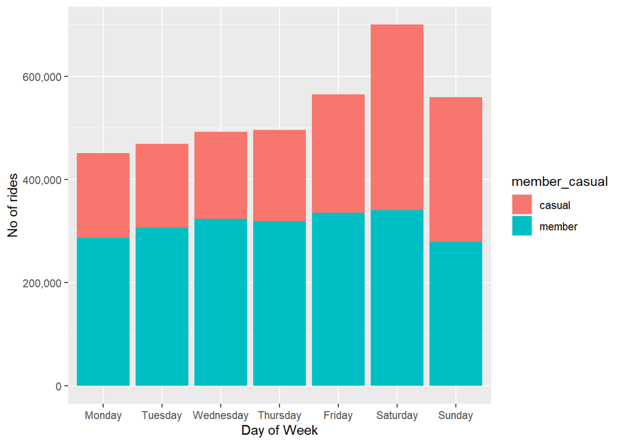

```r
#==============================
# STEP 4: ANALYZE DATA (contd.)
#==============================

# 2) a) Plot no of rides by weekday
ggp2a <- df_all_trips_v2 %>%
  group_by(member_casual, day_of_week) %>%
  summarise(number_of_rides = n(), .groups = "drop") %>%
  arrange(member_casual, day_of_week) %>%
  ggplot(aes(x = day_of_week, y = number_of_rides, fill = member_casual)) + geom_col()
ggp2a + labs(x="Day of Week", y="No of rides") + scale_y_continuous(labels = comma)
```

#### Analysis:

- Maximum no of Total Rides are taken during the weekend
- On Weekdays, most of the rides are taken by members
- However, on weekends roughly half of the rides are taken by casual riders

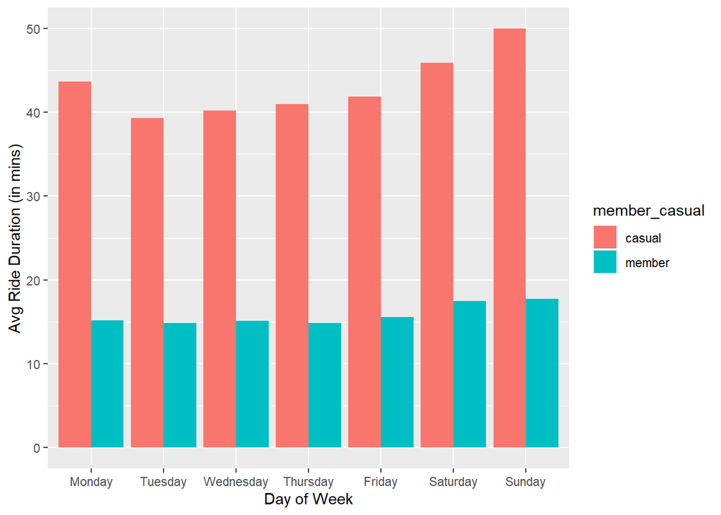

```r
#==============================
# STEP 4: ANALYZE DATA (contd.)
#==============================

# 2) b) Plot avg ride duration by weekday
ggp2b <- df_all_trips_v2 %>%
  group_by(member_casual, day_of_week) %>%
  summarise(avg_duration = mean(ride_length/60), .groups = "drop") %>%
  arrange(member_casual, day_of_week) %>%
  ggplot(aes(x = day_of_week, y = as.numeric(avg_duration), fill = member_casual)) + geom_bar(position="dodge", stat="identity")
ggp2b + labs(x="Day of Week", y="Avg Ride Duration (in mins)")
```

#### Analyis:

- Casual riders on an average take longer trips when using the bikes and the trip length is greater in the weekends
- Members, on the other hand, have a consistent average over the week indicating they’re probably using the bike to commute to work or for regular exercise

### Recommendation 1:

- Focus on targeting casual riders during the weekend
- On weekends, offer discounts for new annual memberships
- Promote benefits of cycling regularly to entice the weekend casual riders to pick up regular cycling like the members

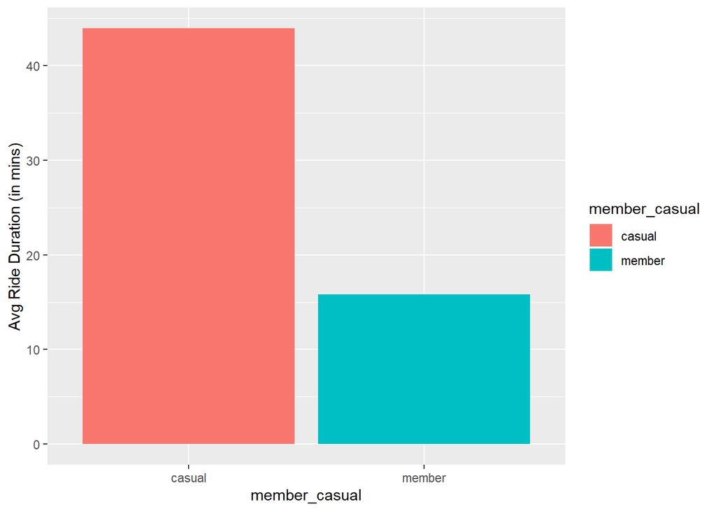

```r
#==============================
# STEP 4: ANALYZE DATA (contd.)
#==============================

# 2) c) Plot avg ride duration by rider type
ggp2c <- df_all_trips_v2 %>%
  group_by(member_casual) %>%
  summarise(avg_duration = mean(ride_length/60), .groups = "drop") %>%
  arrange(member_casual) %>%
  ggplot(aes(x = member_casual, y = as.numeric(avg_duration), fill = member_casual)) + geom_col()
ggp2c + labs(y="Avg Ride Duration (in mins)")
```

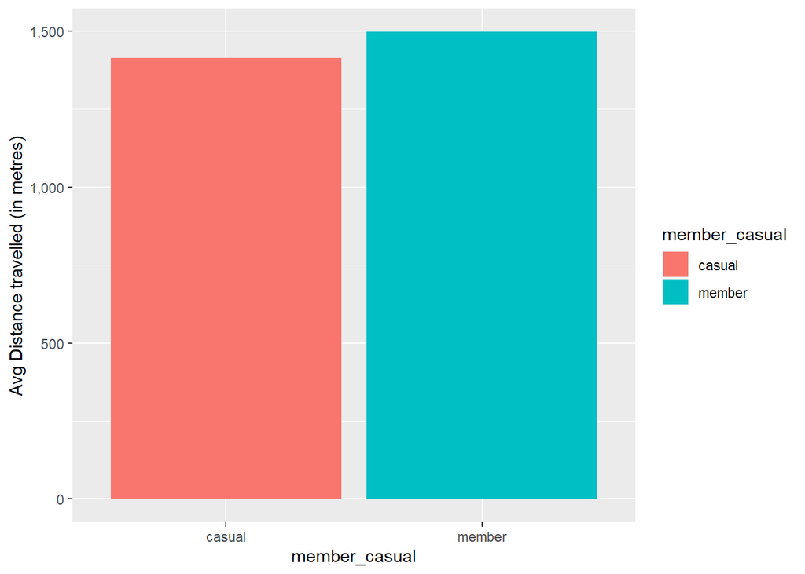

```r
# 2) d) Plot avg distance travelled by rider type
ggp2d <- df_all_trips_v2 %>%
  group_by(member_casual) %>%
  summarise(avg_dist_travelled = mean(dist_travelled), .groups = "drop") %>%
  arrange(member_casual) %>%
  ggplot(aes(x = member_casual, y = avg_dist_travelled, fill = member_casual)) + geom_col()
ggp2d + labs(y="Avg Distance travelled (in metres)") + scale_y_continuous(labels = comma)
```

```r
# Report limitation of round trips
zero_dist <- df_all_trips %>% filter(dist_travelled == 0) %>% nrow()
total_rows <- nrow(df_all_trips)
cat("There are ",zero_dist," (",percent(zero_dist/total_rows),") values with dist_travelled = 0")
```

```
## There are  321534  ( 9% ) values with dist_travelled = 0
```

#### Analyis:

- Casual riders on an average take more time to complete their ride but the distance travelled by them is roughly the same as members, this suggests that casual riders take rides for leisure
- Also, this cements the fact that members are riding fast for routine activities

*Limitation: The above analysis doesn’t consider 9% of trips with dist_travelled = 0 that are either round trips or when the bike was taken but not ridden. This doesn’t skew the results that much and the general analysis would hold true*

### Recommendation 2:

- Conduct leisure activities like guided bicyle tours to attract existing and new casual riders and in-turn open greater potential to convert them to members
- Offer greater exposure and discounts on such activies with membership

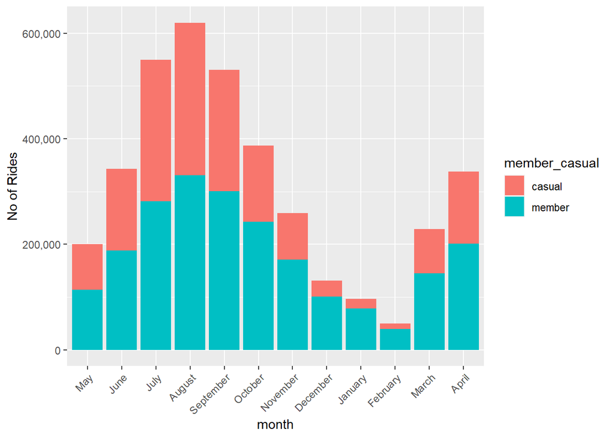

```r
#==============================
# STEP 4: ANALYZE DATA (contd.)
#==============================

# 3) No of rides by month
ggp3 <- df_all_trips_v2 %>%
  group_by(member_casual, month) %>%
  summarise(number_of_rides = n(), .groups = "drop") %>%
  arrange(member_casual, month) %>%
  ggplot(aes(x = month, y = number_of_rides, fill = member_casual)) + geom_col()
ggp3 + labs(y="No of Rides") + scale_y_continuous(labels = comma) + theme(axis.text.x = element_text(angle=45, hjust = 1))
```

#### Analysis:

- Maximum rides are taken during the months form July to September
- The trend suggests that the no of rides taken are very low in the winter season (N.Hemisphere) but they shoot back up in the spring and summer seaons

### Recommendation 3

- Focus on marketing campaigns during the spring and summer months

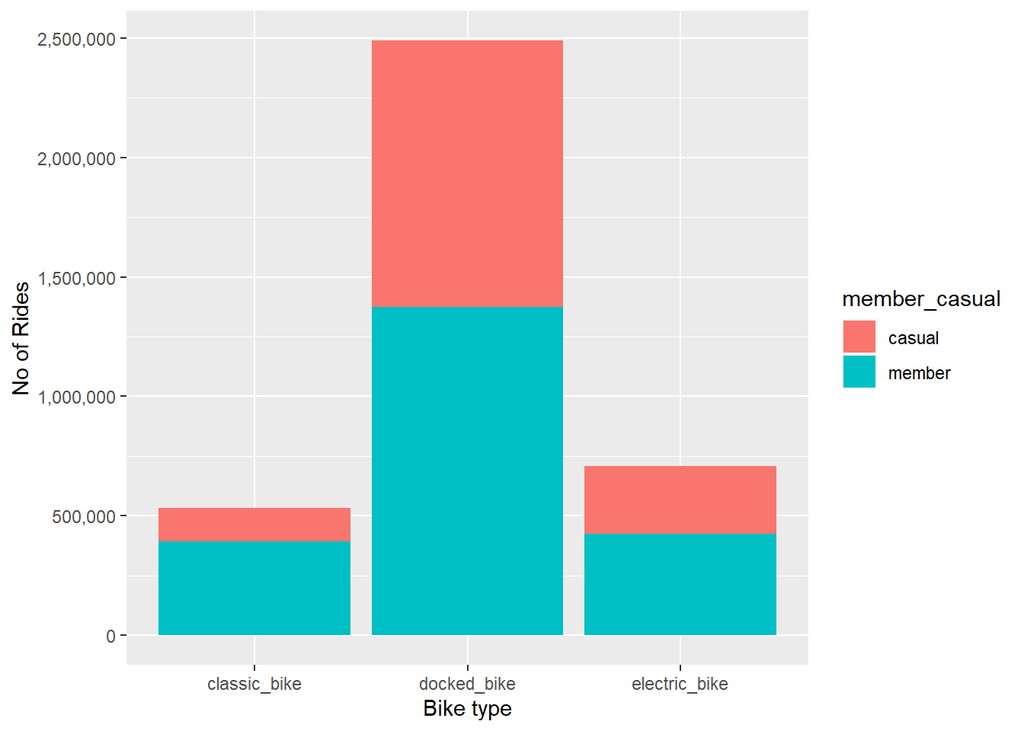

```r
#==============================
# STEP 4: ANALYZE DATA (contd.)
#==============================

# 4) a) Plot no of rides by bike type
ggp4a <- df_all_trips_v2 %>%
  group_by(member_casual, rideable_type) %>%
  summarise(number_of_rides = n(), .groups = "drop") %>%
  arrange(member_casual, rideable_type) %>%
  ggplot(aes(x = rideable_type, y = number_of_rides, fill = member_casual)) + geom_col()
ggp4a + labs(x="Bike type", y="No of Rides") + scale_y_continuous(labels = comma)
```

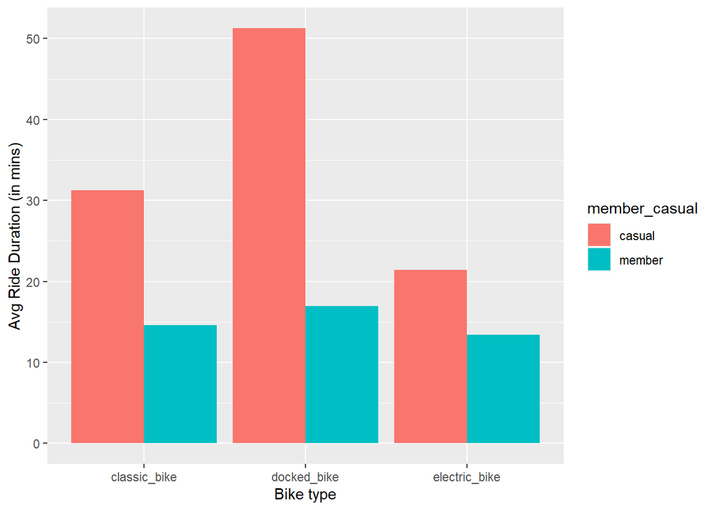

```r
# 4) b) Plot avg ride duration by bike type
ggp4b <- df_all_trips_v2 %>%
  group_by(member_casual, rideable_type) %>%
  summarise(average_duration = mean(ride_length/60), .groups = "drop") %>%
  arrange(member_casual, rideable_type) %>%
  ggplot(aes(x = rideable_type, y = as.numeric(average_duration), fill = member_casual)) + geom_bar(position="dodge", stat="identity")
ggp4b + labs(x="Bike type", y="Avg Ride Duration (in mins)") + scale_y_continuous(labels = comma)
```

#### Analysis:

- Docked bike is the most used bike
- Docked bike also has the highest average ride duration

### Recommendation 4

- Keep adequate no of docked bikes in supply throughout the City

## Conclusion:

- There is a great opprortunity to convert casual riders to members
- Most traffic of users is during the weekends
- Discounting annual memberships and promoting benefits of cycling can help convert casual riders to members
- Casual riders mostly take trips for leisure
- Conducting planned leisure activities could atttract more people
- The spring & summer months are the best times to launch a marketing campaign
- The docked bike is the most used bike